# 💻 Laptop Market Insights: Analyzing Specifications & Prices

## 🎯 Objective

Have you ever wondered **which laptop specifications impact the price the most?** Or **which brands offer the best value for money?** This notebook dives into the **laptop market**, breaking down key specifications and trends to uncover valuable insights.

## 🔍 What's Inside?

We'll explore a dataset containing details such as:  
✅ **Brands** (Dell, HP, Apple, etc.)  
✅ **Processors** (Intel, AMD, Apple M-series)  
✅ **RAM & Storage** (How much is enough?)  
✅ **Graphics Cards** (Gaming vs. Everyday Use)  
✅ **Pricing Trends** (What makes a laptop expensive?)

## 📊 How We'll Analyze the Data

- **Data Preprocessing & Cleaning** 🛠️
- **Visualizing Trends & Patterns** 📈
- **Identifying Price-Performance Relationships** 🔎
- **Finding the Best Value Laptops (Optional)** 💰

By the end of this notebook, you'll have a **data-driven perspective on the laptop market**, helping you make better purchasing or business decisions.

📝 **Let's explore the data! 🚀**

```python
import pandas as pd
import numpy as np
import matplotlib.pyplot as plt
import seaborn as sns
from scipy  import stats

import warnings
warnings.filterwarnings('ignore')
```

```python
df=pd.read_csv("laptop_data.csv")
df
```

|  | Unnamed: 0 | Company | TypeName | Inches | ScreenResolution | Cpu | Ram | Memory | Gpu | OpSys | Weight | Price |
| --- | --- | --- | --- | --- | --- | --- | --- | --- | --- | --- | --- | --- |
| 0 | 0 | Apple | Ultrabook | 13.3 | IPS Panel Retina Display 2560x1600 | Intel Core i5 2.3GHz | 8GB | 128GB SSD | Intel Iris Plus Graphics 640 | macOS | 1.37kg | 71378.6832 |
| 1 | 1 | Apple | Ultrabook | 13.3 | 1440x900 | Intel Core i5 1.8GHz | 8GB | 128GB Flash Storage | Intel HD Graphics 6000 | macOS | 1.34kg | 47895.5232 |
| 2 | 2 | HP | Notebook | 15.6 | Full HD 1920x1080 | Intel Core i5 7200U 2.5GHz | 8GB | 256GB SSD | Intel HD Graphics 620 | No OS | 1.86kg | 30636.0000 |
| 3 | 3 | Apple | Ultrabook | 15.4 | IPS Panel Retina Display 2880x1800 | Intel Core i7 2.7GHz | 16GB | 512GB SSD | AMD Radeon Pro 455 | macOS | 1.83kg | 135195.3360 |
| 4 | 4 | Apple | Ultrabook | 13.3 | IPS Panel Retina Display 2560x1600 | Intel Core i5 3.1GHz | 8GB | 256GB SSD | Intel Iris Plus Graphics 650 | macOS | 1.37kg | 96095.8080 |
| ... | ... | ... | ... | ... | ... | ... | ... | ... | ... | ... | ... | ... |
| 1298 | 1298 | Lenovo | 2 in 1 Convertible | 14.0 | IPS Panel Full HD / Touchscreen 1920x1080 | Intel Core i7 6500U 2.5GHz | 4GB | 128GB SSD | Intel HD Graphics 520 | Windows 10 | 1.8kg | 33992.6400 |
| 1299 | 1299 | Lenovo | 2 in 1 Convertible | 13.3 | IPS Panel Quad HD+ / Touchscreen 3200x1800 | Intel Core i7 6500U 2.5GHz | 16GB | 512GB SSD | Intel HD Graphics 520 | Windows 10 | 1.3kg | 79866.7200 |
| 1300 | 1300 | Lenovo | Notebook | 14.0 | 1366x768 | Intel Celeron Dual Core N3050 1.6GHz | 2GB | 64GB Flash Storage | Intel HD Graphics | Windows 10 | 1.5kg | 12201.1200 |
| 1301 | 1301 | HP | Notebook | 15.6 | 1366x768 | Intel Core i7 6500U 2.5GHz | 6GB | 1TB HDD | AMD Radeon R5 M330 | Windows 10 | 2.19kg | 40705.9200 |
| 1302 | 1302 | Asus | Notebook | 15.6 | 1366x768 | Intel Celeron Dual Core N3050 1.6GHz | 4GB | 500GB HDD | Intel HD Graphics | Windows 10 | 2.2kg | 19660.3200 |

1303 rows × 12 columns

✲ There are 1303 and 12 columns.

•Unnamed: The index of the dataset.

•Company: The brand or manufacturer of the laptop.

•TypeName: The category or type of the laptop.

•Inches: The size of the laptop's screen, measured in inches.

•ScreenResolution: The screen resolution of the laptop.

•Cpu: The processor in the laptop, including its model and speed.

•Ram: The amount of RAM in the laptop, typically measured in GB.

•Memory: The storage capacity of the laptop, either in SSD or HDD.

•Gpu: The type of graphics processing unit (GPU) installed in the laptop.

•OpSys: The operating system of the laptop.

•Weight: The weight of the laptop in kilograms.

•Price: The price of the laptop in the dataset.

```python
df.info()
```

```
<class 'pandas.core.frame.DataFrame'>
RangeIndex: 1303 entries, 0 to 1302
Data columns (total 12 columns):
 #   Column            Non-Null Count  Dtype
---  ------            --------------  -----
 0   Unnamed: 0        1303 non-null   int64
 1   Company           1303 non-null   object
 2   TypeName          1303 non-null   object
 3   Inches            1303 non-null   float64
 4   ScreenResolution  1303 non-null   object
 5   Cpu               1303 non-null   object
 6   Ram               1303 non-null   object
 7   Memory            1303 non-null   object
 8   Gpu               1303 non-null   object
 9   OpSys             1303 non-null   object
 10  Weight            1303 non-null   object
 11  Price             1303 non-null   float64
dtypes: float64(2), int64(1), object(9)
memory usage: 122.3+ KB
```

```python
df.shape
```

```
(1303, 12)
```

```python
df.describe().T
```

|  | count | mean | std | min | 25% | 50% | 75% | max |
| --- | --- | --- | --- | --- | --- | --- | --- | --- |
| Unnamed: 0 | 1303.0 | 651.000000 | 376.288010 | 0.00 | 325.50 | 651.00 | 976.5000 | 1302.00 |
| Inches | 1303.0 | 15.017191 | 1.426304 | 10.10 | 14.00 | 15.60 | 15.6000 | 18.40 |
| Price | 1303.0 | 59870.042910 | 37243.201786 | 9270.72 | 31914.72 | 52054.56 | 79274.2464 | 324954.72 |

```python
#Let's remove unnecessary columns
df.drop(columns="Unnamed: 0",inplace=True)
```

```python
#Check for duplicates
duplicate_values=df.duplicated().sum()
duplicate_values
```

```
29
```

```python
#Remove duplicates
df.drop_duplicates(inplace=True)
```

```python
df.duplicated().sum()
```

```
0
```

```python
df.dtypes
```

```
Company              object
TypeName             object
Inches              float64
ScreenResolution     object
Cpu                  object
Ram                  object
Memory               object
Gpu                  object
OpSys                object
Weight               object
Price               float64
dtype: object
```

```python
#Remove unwanted characters and convert to appropriate type
df.Weight=df.Weight.str.strip("kg").astype("float")

df["Price"]=df["Price"].round(2)

df['Ram'] = df['Ram'].str.replace('GB', '').astype(int)

df['MemorySize'] = df['Memory'].str.extract(r'(\d+GB)')
df['MemoryType'] = df['Memory'].str.extract(r'\d+GB\s*(.*)')

df.drop(columns=["Memory"],inplace=True)
```

```python
df.Cpu.value_counts()
```

```
Cpu
Intel Core i5 7200U 2.5GHz     190
Intel Core i7 7700HQ 2.8GHz    146
Intel Core i7 7500U 2.7GHz     132
Intel Core i7 8550U 1.8GHz      73
Intel Core i5 8250U 1.6GHz      72
                              ...
Intel Core M M3-6Y30 0.9GHz      1
AMD A9-Series 9420 2.9GHz        1
Intel Core i5 2.9GHz             1
AMD A6-Series 7310 2GHz          1
AMD A9-Series 9410 2.9GHz        1
Name: count, Length: 118, dtype: int64
```

```python
df['Brand'] = df['Cpu'].str.split(' ').str[0]
df['ClockSpeed'] = df['Cpu'].str.extract(r'(\d+\.\d+GHz)')
```

```python
#The replace method standardizes operating system names. This ensures consistency for easier analysis.
df['OpSys'] = df['OpSys'].replace({
    'macOS': 'Mac',
    'Windows 10': 'Windows',
    'No OS': 'None',
    'Linux': 'Linux'
})
```

```python
df.TypeName.value_counts()
```

```
TypeName
Notebook              706
Gaming                205
Ultrabook             194
2 in 1 Convertible    117
Workstation            29
Netbook                23
Name: count, dtype: int64
```

```python
df.TypeName.str.replace(" ","_")
```

```
0                Ultrabook
1                Ultrabook
2                 Notebook
3                Ultrabook
4                Ultrabook
               ...
1269              Notebook
1270    2_in_1_Convertible
1271    2_in_1_Convertible
1272              Notebook
1273              Notebook
Name: TypeName, Length: 1274, dtype: object
```

```python
#The ScreenResolution column was split into two new columns: PanelType and Resolution.
#The original column was then dropped, and PanelType was cleaned and updated to include whether the device has a touchscreen (Yes or No)
df['PanelType'] = df['ScreenResolution'].apply(lambda x: ' '.join(x.split()[:-1]))
df['Resolution'] = df['ScreenResolution'].apply(lambda x: x.split()[-1])

df.drop(columns="ScreenResolution",inplace=True)

df['PanelType'] = df['PanelType'].str.replace("IPS Panel", "", regex=False).str.strip()
df['Touchscreen'] = df['PanelType'].apply(lambda x: 'Yes' if 'Touchscreen' in x else 'No')

df['PanelType'] = df['PanelType'].str.replace(" / Touchscreen", "", regex=False).str.strip()
df['PanelType'] = df['PanelType'].replace('', 'Unknown')
```

```python
df.sample()
```

|  | Company | TypeName | Inches | Cpu | Ram | Gpu | OpSys | Weight | Price | MemorySize | MemoryType | Brand | ClockSpeed | PanelType | Resolution | Touchscreen |
| --- | --- | --- | --- | --- | --- | --- | --- | --- | --- | --- | --- | --- | --- | --- | --- | --- |
| 517 | Asus | Gaming | 15.6 | Intel Core i7 7700HQ 2.8GHz | 24 | Nvidia GeForce GTX1080 | Windows | 2.24 | 158135.04 | 512GB | SSD | Intel | 2.8GHz | Full HD | 1920x1080 | No |

```python
#Let's check for outliers in numerical columns
```

```python
df.dtypes
```

```
Company         object
TypeName        object
Inches         float64
Cpu             object
Ram              int32
Gpu             object
OpSys           object
Weight         float64
Price          float64
MemorySize      object
MemoryType      object
Brand           object
ClockSpeed      object
PanelType       object
Resolution      object
Touchscreen     object
dtype: object
```

```python
z_scores=np.abs(stats.zscore(df["Inches"]))
outliers=np.where(z_scores>3)[0]
df.iloc[outliers]
```

|  | Company | TypeName | Inches | Cpu | Ram | Gpu | OpSys | Weight | Price | MemorySize | MemoryType | Brand | ClockSpeed | PanelType | Resolution | Touchscreen |
| --- | --- | --- | --- | --- | --- | --- | --- | --- | --- | --- | --- | --- | --- | --- | --- | --- |
| 50 | Lenovo | 2 in 1 Convertible | 10.1 | Intel Atom x5-Z8550 1.44GHz | 4 | Intel HD Graphics 400 | Android | 0.69 | 16996.32 | 64GB | Flash Storage | Intel | 1.44GHz | Touchscreen | 1920x1200 | Yes |
| 1082 | Lenovo | 2 in 1 Convertible | 10.1 | Intel Atom x5-Z8550 1.44GHz | 4 | Intel HD Graphics 400 | Windows | 0.69 | 34433.27 | 64GB | Flash Storage | Intel | 1.44GHz | Touchscreen | 1920x1200 | Yes |
| 1114 | Lenovo | 2 in 1 Convertible | 10.1 | Intel Atom x5-Z8550 1.44GHz | 4 | Intel HD Graphics 400 | Android | 0.69 | 29250.72 | 64GB | Flash Storage | Intel | 1.44GHz | Touchscreen | 1920x1200 | Yes |
| 1126 | Lenovo | 2 in 1 Convertible | 10.1 | Intel Atom x5-Z8550 1.44GHz | 4 | Intel HD Graphics 400 | Windows | 0.69 | 25521.12 | 64GB | Flash Storage | Intel | 1.44GHz | Touchscreen | 1920x1200 | Yes |

```python
z_scores2=np.abs(stats.zscore(df["Ram"]))
outliers2=np.where(z_scores2>3.5)[0]
df.iloc[outliers2]
```

|  | Company | TypeName | Inches | Cpu | Ram | Gpu | OpSys | Weight | Price | MemorySize | MemoryType | Brand | ClockSpeed | PanelType | Resolution | Touchscreen |
| --- | --- | --- | --- | --- | --- | --- | --- | --- | --- | --- | --- | --- | --- | --- | --- | --- |
| 177 | MSI | Gaming | 18.4 | Intel Core i7 6920HQ 2.9GHz | 32 | Nvidia GTX 980 SLI | Windows | 4.40 | 149130.72 | 512GB | SSD + 1TB HDD | Intel | 2.9GHz | Full HD | 1920x1080 | No |
| 196 | Razer | Gaming | 17.3 | Intel Core i7 7820HK 2.9GHz | 32 | Nvidia GeForce GTX 1080 | Windows | 3.49 | 324954.72 | NaN | NaN | Intel | 2.9GHz | 4K Ultra HD | 3840x2160 | Yes |
| 238 | Asus | Gaming | 17.3 | Intel Core i7 7820HK 2.9GHz | 32 | Nvidia GeForce GTX 1080 | Windows | 4.70 | 207259.20 | 512GB | SSD + 1TB HDD | Intel | 2.9GHz | Full HD | 1920x1080 | No |
| 329 | Dell | Notebook | 15.6 | Intel Core i7 7700HQ 2.8GHz | 32 | Nvidia GeForce GTX 1050 | Windows | 2.06 | 140605.92 | NaN | NaN | Intel | 2.8GHz | 4K Ultra HD | 3840x2160 | Yes |
| 491 | Toshiba | Ultrabook | 13.3 | Intel Core i7 7500U 2.7GHz | 32 | Intel HD Graphics 620 | Windows | 1.05 | 149130.72 | 512GB | SSD | Intel | 2.7GHz | Full HD | 1920x1080 | Yes |
| 577 | Lenovo | Gaming | 17.3 | Intel Core i7 6820HK 2.7GHz | 32 | Nvidia GeForce GTX 1070 | Windows | 4.60 | 141884.64 | 256GB | SSD + 1TB HDD | Intel | 2.7GHz | Full HD | 1920x1080 | No |
| 610 | Lenovo | Notebook | 15.6 | Intel Xeon E3-1535M v6 3.1GHz | 32 | Nvidia Quadro M2200M | Windows | 2.50 | 261018.72 | NaN | NaN | Intel | 3.1GHz | 4K Ultra HD | 3840x2160 | No |
| 650 | Asus | Gaming | 17.3 | Intel Core i7 6820HK 2.7GHz | 32 | Nvidia GeForce GTX 1080 | Windows | 3.80 | 149130.72 | 512GB | SSD | Intel | 2.7GHz | Full HD | 1920x1080 | No |
| 659 | Dell | Gaming | 17.3 | Intel Core i7 7700HQ 2.8GHz | 32 | Nvidia GeForce GTX 1070 | Windows | 4.42 | 167691.87 | 512GB | SSD + 1TB HDD | Intel | 2.8GHz | 4K Ultra HD | 3840x2160 | No |
| 723 | Dell | Gaming | 17.3 | Intel Core i7 7700HQ 2.8GHz | 32 | Nvidia GeForce GTX 1070 | Windows | 4.36 | 194972.83 | NaN | NaN | Intel | 2.8GHz | 4K Ultra HD | 3840x2160 | No |
| 780 | Dell | Gaming | 17.3 | Intel Core i7 7700HQ 2.8GHz | 32 | Nvidia GeForce GTX 1070M | Windows | 4.42 | 191211.26 | NaN | NaN | Intel | 2.8GHz | Full HD | 1920x1080 | No |
| 830 | Razer | Gaming | 17.3 | Intel Core i7 7820HK 2.9GHz | 32 | Nvidia GeForce GTX 1080 | Windows | 3.49 | 292986.72 | 512GB | SSD | Intel | 2.9GHz | 4K Ultra HD | 3840x2160 | Yes |
| 841 | Dell | Gaming | 17.3 | Intel Core i7 7700HQ 2.8GHz | 32 | Nvidia GeForce GTX 1070 | Windows | 4.42 | 163723.58 | 512GB | SSD + 1TB HDD | Intel | 2.8GHz | Full HD | 1920x1080 | No |
| 901 | Asus | Gaming | 17.3 | Intel Core i7 6820HK 2.7GHz | 32 | Nvidia GeForce GTX 980M | Windows | 3.58 | 68145.12 | 256GB | SSD + 256GB SSD | Intel | 2.7GHz | Full HD | 1920x1080 | No |
| 968 | Dell | Gaming | 17.3 | Intel Core i7 7700HQ 2.8GHz | 32 | Nvidia GeForce GTX 1070 | Windows | 4.42 | 167778.72 | 256GB | SSD + 1TB HDD | Intel | 2.8GHz | Full HD | 1920x1080 | No |
| 972 | Dell | Gaming | 17.3 | Intel Core i7 6700HQ 2.6GHz | 32 | Nvidia GeForce GTX 1070 | Windows | 4.42 | 149184.00 | 256GB | SSD + 1TB HDD | Intel | 2.6GHz | Full HD | 1920x1080 | No |
| 1066 | Asus | Gaming | 17.3 | Intel Core i7 6820HK 2.7GHz | 64 | Nvidia GeForce GTX 980 | Windows | 3.58 | 211788.00 | NaN | NaN | Intel | 2.7GHz | Full HD | 1920x1080 | No |
| 1081 | Lenovo | Gaming | 17.3 | Intel Core i7 6820HK 2.7GHz | 32 | Nvidia GeForce GTX 980M | Windows | 4.60 | 172627.20 | 512GB | SSD + 1.0TB Hybrid | Intel | 2.7GHz | Full HD | 1920x1080 | No |

```python
z_scores3=np.abs(stats.zscore(df["Weight"]))
outliers3=np.where(z_scores3>3.5)[0]
df.iloc[outliers3]
```

|  | Company | TypeName | Inches | Cpu | Ram | Gpu | OpSys | Weight | Price | MemorySize | MemoryType | Brand | ClockSpeed | PanelType | Resolution | Touchscreen |
| --- | --- | --- | --- | --- | --- | --- | --- | --- | --- | --- | --- | --- | --- | --- | --- | --- |
| 177 | MSI | Gaming | 18.4 | Intel Core i7 6920HQ 2.9GHz | 32 | Nvidia GTX 980 SLI | Windows | 4.40 | 149130.72 | 512GB | SSD + 1TB HDD | Intel | 2.9GHz | Full HD | 1920x1080 | No |
| 224 | Dell | Gaming | 17.3 | Intel Core i7 7700HQ 2.8GHz | 16 | Nvidia GeForce GTX 1060 | Windows | 4.42 | 130873.80 | 256GB | SSD + 1TB HDD | Intel | 2.8GHz | Full HD | 1920x1080 | No |
| 238 | Asus | Gaming | 17.3 | Intel Core i7 7820HK 2.9GHz | 32 | Nvidia GeForce GTX 1080 | Windows | 4.70 | 207259.20 | 512GB | SSD + 1TB HDD | Intel | 2.9GHz | Full HD | 1920x1080 | No |
| 424 | Dell | Gaming | 17.3 | Intel Core i7 7820HK 2.9GHz | 16 | Nvidia GeForce GTX 1070 | Windows | 4.42 | 149130.72 | 256GB | SSD + 1TB HDD | Intel | 2.9GHz | Unknown | 2560x1440 | No |
| 456 | Dell | Notebook | 17.3 | Intel Core i7 7700HQ 2.7GHz | 8 | Nvidia GeForce GTX 1060 | Windows | 4.42 | 109010.88 | NaN | NaN | Intel | 2.7GHz | Full HD | 1920x1080 | No |
| 530 | Dell | Gaming | 17.3 | Intel Core i7 7700HQ 2.8GHz | 16 | Nvidia GeForce GTX 1070 | Windows | 4.42 | 160520.39 | 128GB | SSD + 1TB HDD | Intel | 2.8GHz | Full HD | 1920x1080 | No |
| 552 | Dell | Gaming | 17.3 | Intel Core i7 7700HQ 2.8GHz | 16 | Nvidia GeForce GTX 1070 | Windows | 4.42 | 143802.72 | 256GB | SSD + 1TB HDD | Intel | 2.8GHz | Full HD | 1920x1080 | No |
| 577 | Lenovo | Gaming | 17.3 | Intel Core i7 6820HK 2.7GHz | 32 | Nvidia GeForce GTX 1070 | Windows | 4.60 | 141884.64 | 256GB | SSD + 1TB HDD | Intel | 2.7GHz | Full HD | 1920x1080 | No |
| 585 | MSI | Gaming | 17.3 | Intel Core i7 6820HK 2.7GHz | 16 | Nvidia GeForce GTX 980M | Windows | 4.50 | 125154.72 | 128GB | SSD + 1TB HDD | Intel | 2.7GHz | Full HD | 1920x1080 | No |
| 659 | Dell | Gaming | 17.3 | Intel Core i7 7700HQ 2.8GHz | 32 | Nvidia GeForce GTX 1070 | Windows | 4.42 | 167691.87 | 512GB | SSD + 1TB HDD | Intel | 2.8GHz | 4K Ultra HD | 3840x2160 | No |
| 758 | Dell | Gaming | 15.6 | Intel Core i7 7700HQ 2.8GHz | 16 | Nvidia GeForce GTX 1070 | Windows | 4.42 | 152859.79 | 256GB | SSD + 1TB HDD | Intel | 2.8GHz | 4K Ultra HD | 3840x2160 | No |
| 780 | Dell | Gaming | 17.3 | Intel Core i7 7700HQ 2.8GHz | 32 | Nvidia GeForce GTX 1070M | Windows | 4.42 | 191211.26 | NaN | NaN | Intel | 2.8GHz | Full HD | 1920x1080 | No |
| 841 | Dell | Gaming | 17.3 | Intel Core i7 7700HQ 2.8GHz | 32 | Nvidia GeForce GTX 1070 | Windows | 4.42 | 163723.58 | 512GB | SSD + 1TB HDD | Intel | 2.8GHz | Full HD | 1920x1080 | No |
| 968 | Dell | Gaming | 17.3 | Intel Core i7 7700HQ 2.8GHz | 32 | Nvidia GeForce GTX 1070 | Windows | 4.42 | 167778.72 | 256GB | SSD + 1TB HDD | Intel | 2.8GHz | Full HD | 1920x1080 | No |
| 972 | Dell | Gaming | 17.3 | Intel Core i7 6700HQ 2.6GHz | 32 | Nvidia GeForce GTX 1070 | Windows | 4.42 | 149184.00 | 256GB | SSD + 1TB HDD | Intel | 2.6GHz | Full HD | 1920x1080 | No |
| 1048 | Lenovo | Gaming | 17.3 | Intel Core i7 6700HQ 2.6GHz | 16 | Nvidia GeForce GTX 980M | Windows | 4.60 | 122010.67 | 128GB | SSD + 1TB HDD | Intel | 2.6GHz | Full HD | 1920x1080 | No |
| 1081 | Lenovo | Gaming | 17.3 | Intel Core i7 6820HK 2.7GHz | 32 | Nvidia GeForce GTX 980M | Windows | 4.60 | 172627.20 | 512GB | SSD + 1.0TB Hybrid | Intel | 2.7GHz | Full HD | 1920x1080 | No |
| 1116 | Lenovo | Gaming | 17.3 | Intel Core i7 6820HK 2.7GHz | 16 | Nvidia GeForce GTX 980M | Windows | 4.60 | 146519.47 | 256GB | SSD + 1.0TB Hybrid | Intel | 2.7GHz | Full HD | 1920x1080 | No |

```python
z_scores4=np.abs(stats.zscore(df["Price"]))
outliers4=np.where(z_scores4>3.5)[0]
df.iloc[outliers4]
```

|  | Company | TypeName | Inches | Cpu | Ram | Gpu | OpSys | Weight | Price | MemorySize | MemoryType | Brand | ClockSpeed | PanelType | Resolution | Touchscreen |
| --- | --- | --- | --- | --- | --- | --- | --- | --- | --- | --- | --- | --- | --- | --- | --- | --- |
| 196 | Razer | Gaming | 17.3 | Intel Core i7 7820HK 2.9GHz | 32 | Nvidia GeForce GTX 1080 | Windows | 3.49 | 324954.72 | NaN | NaN | Intel | 2.9GHz | 4K Ultra HD | 3840x2160 | Yes |
| 238 | Asus | Gaming | 17.3 | Intel Core i7 7820HK 2.9GHz | 32 | Nvidia GeForce GTX 1080 | Windows | 4.70 | 207259.20 | 512GB | SSD + 1TB HDD | Intel | 2.9GHz | Full HD | 1920x1080 | No |
| 610 | Lenovo | Notebook | 15.6 | Intel Xeon E3-1535M v6 3.1GHz | 32 | Nvidia Quadro M2200M | Windows | 2.50 | 261018.72 | NaN | NaN | Intel | 3.1GHz | 4K Ultra HD | 3840x2160 | No |
| 723 | Dell | Gaming | 17.3 | Intel Core i7 7700HQ 2.8GHz | 32 | Nvidia GeForce GTX 1070 | Windows | 4.36 | 194972.83 | NaN | NaN | Intel | 2.8GHz | 4K Ultra HD | 3840x2160 | No |
| 749 | HP | Workstation | 17.3 | Intel Xeon E3-1535M v5 2.9GHz | 16 | Nvidia Quadro M2000M | Windows 7 | 3.00 | 233845.92 | 256GB | SSD | Intel | 2.9GHz | Full HD | 1920x1080 | No |
| 780 | Dell | Gaming | 17.3 | Intel Core i7 7700HQ 2.8GHz | 32 | Nvidia GeForce GTX 1070M | Windows | 4.42 | 191211.26 | NaN | NaN | Intel | 2.8GHz | Full HD | 1920x1080 | No |
| 830 | Razer | Gaming | 17.3 | Intel Core i7 7820HK 2.9GHz | 32 | Nvidia GeForce GTX 1080 | Windows | 3.49 | 292986.72 | 512GB | SSD | Intel | 2.9GHz | 4K Ultra HD | 3840x2160 | Yes |
| 1066 | Asus | Gaming | 17.3 | Intel Core i7 6820HK 2.7GHz | 64 | Nvidia GeForce GTX 980 | Windows | 3.58 | 211788.00 | NaN | NaN | Intel | 2.7GHz | Full HD | 1920x1080 | No |
| 1136 | HP | Workstation | 17.3 | Intel Core i7 6700HQ 2.6GHz | 8 | Nvidia Quadro M3000M | Windows 7 | 3.00 | 210424.03 | 256GB | SSD | Intel | 2.6GHz | Full HD | 1920x1080 | No |

```python
df = df.drop(outliers4)
```

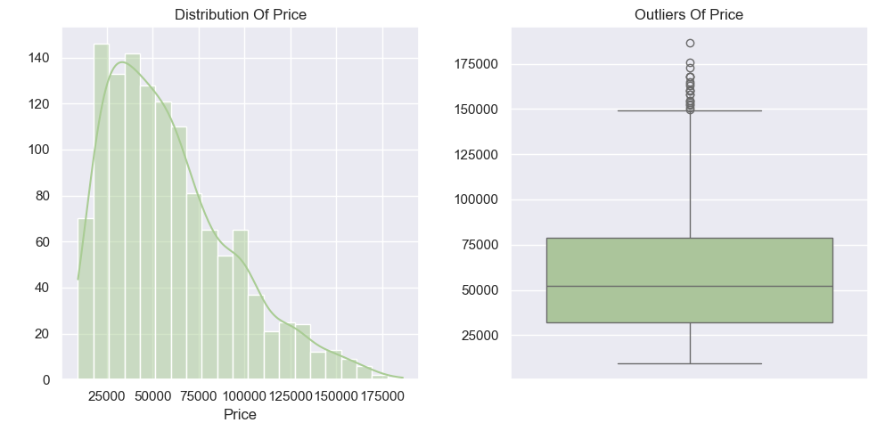

```python
#Distribution of Price
sns.color_palette("crest", as_cmap=True)
sns.set_theme(style="darkgrid")
plt.figure(figsize=(10,5))

plt.subplot(1,2,1)
sns.histplot(df.Price, kde=True,color="#A9CC94")
plt.title("Distribution Of Price")
plt.xlabel("Price")
plt.ylabel(" ")

plt.subplot(1,2,2)
sns.boxplot(df.Price,color="#A9CC94")
plt.title("Outliers Of Price")
plt.ylabel(" ")
plt.tight_layout()
plt.show()
```

•The price distribution shows a right-skewed pattern, indicating most devices are in the lower price range, with fewer high-priced outliers. The box plot confirms the presence of outliers significantly above the upper quartile. This highlights price variability and the impact of premium devices on the dataset.

```python
#Company-wise Analysis
df.Company.value_counts()
```

```
Company
Dell         289
Lenovo       288
HP           266
Asus         149
Acer         101
MSI           54
Toshiba       48
Apple         21
Samsung        9
Mediacom       7
Microsoft      6
Razer          5
Xiaomi         4
Vero           4
Chuwi          3
Google         3
Fujitsu        3
LG             3
Huawei         2
Name: count, dtype: int64
```

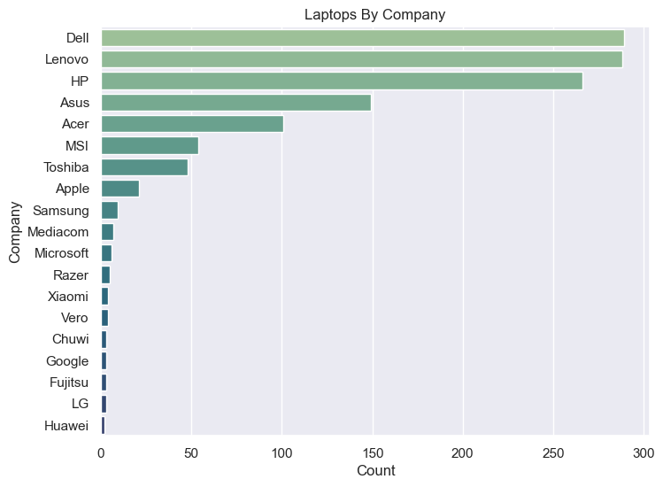

```python
plt.figure(figsize=(8,6))

sns.barplot(x=df.Company.value_counts(),y=df.Company.value_counts().index,palette="crest")
plt.title("Laptops By Company")
plt.xlabel("Count")
plt.ylabel("Company")
plt.show()
```

```python
avg_price=df.groupby("Company")["Price"].mean()
avg_price
```

```
Company
Acer          33750.986040
Apple         83340.499524
Asus          58138.892819
Chuwi         16745.726667
Dell          63000.615225
Fujitsu       38841.120000
Google        89386.080000
HP            56321.753271
Huawei        75870.720000
LG           111834.720000
Lenovo        57577.028437
MSI           92116.225556
Mediacom      15717.600000
Microsoft     85903.788333
Razer        126007.200000
Samsung       75308.320000
Toshiba       67549.050000
Vero          11584.402500
Xiaomi        60390.882500
Name: Price, dtype: float64
```

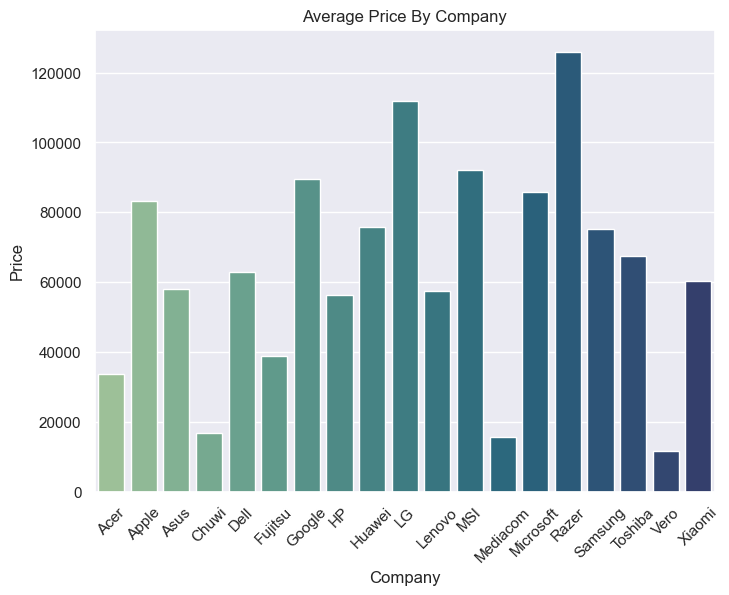

```python
plt.figure(figsize=(8,6))

sns.barplot(x=avg_price.index,y=avg_price,palette="crest")
plt.title("Average Price By Company")
plt.xlabel("Company")
plt.ylabel("Price")
plt.xticks(rotation=45)
plt.show()
```

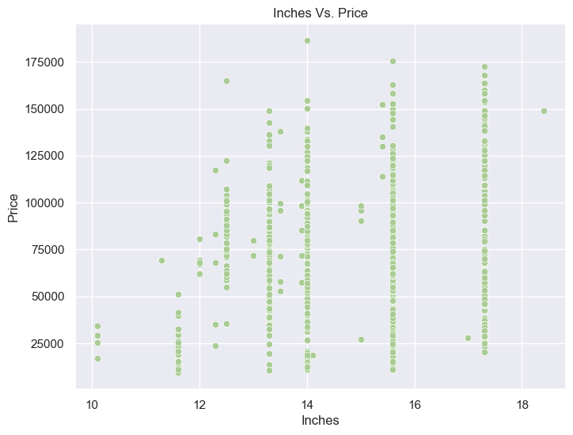

```python
#Relationship between Screen Size and Price
plt.figure(figsize=(8,6))

sns.scatterplot(x=df.Inches,y=df.Price,color="#A9CC94")
plt.title("Inches Vs. Price")
plt.xlabel("Inches")
plt.ylabel("Price")

plt.show()
```

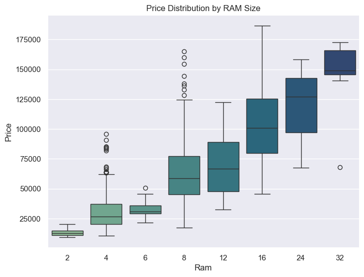

```python
#RAM vs Price Analysis
plt.figure(figsize=(8,6))

sns.boxplot(x=df.Ram,y=df.Price,palette="crest")
plt.title("Price Distribution by RAM Size")
plt.xlabel("Ram")
plt.ylabel("Price")
plt.show()
```

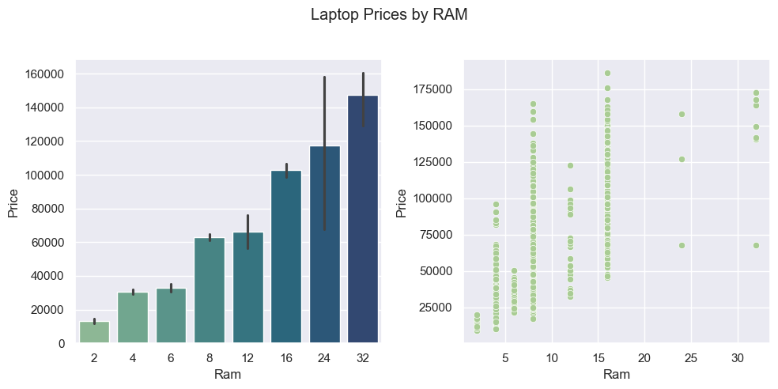

```python
fig, axes=plt.subplots(1,2,figsize=(10,5))

plt.suptitle("Laptop Prices by RAM")

sns.barplot(x=df.Ram,y=df.Price,ax=axes[0],palette="crest")
axes[0].set_xlabel("Ram")
axes[0].set_ylabel("Price")


sns.scatterplot(x=df.Ram,y=df.Price,ax=axes[1],color="#A9CC94")
axes[1].set_title(" ")
axes[1].set_xlabel("Ram")
axes[1].set_ylabel("Price")

plt.tight_layout()
plt.show()
```

•The analysis shows a clear positive correlation between RAM size and laptop price, with higher RAM configurations generally associated with increased costs. However, there is noticeable variability within each RAM category, indicating that price is also influenced by other factors such as brand, performance, and additional features. This trend highlights the significance of RAM as a key determinant of laptop pricing while acknowledging the role of other specifications in driving price differences.

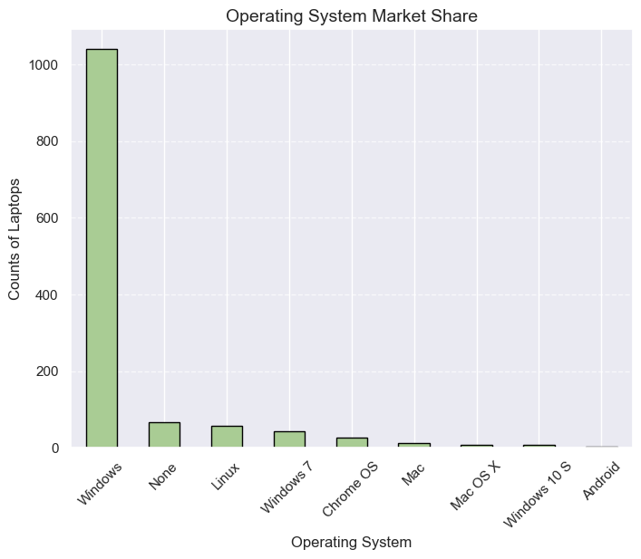

```python
#Operating System Market Share
opsys_counts = df['OpSys'].value_counts()

plt.figure(figsize=(8,6))
opsys_counts.plot(kind='bar', color="#A9CC94", edgecolor='black')
plt.title("Operating System Market Share", fontsize=14)
plt.xlabel("Operating System", fontsize=12)
plt.ylabel("Counts of Laptops", fontsize=12)
plt.xticks(rotation=45)
plt.grid(axis='y', linestyle='--', alpha=0.7)
plt.show()
```

•The analysis reveals that Windows dominates the operating system market share for laptops by a significant margin, indicating its widespread adoption and preference among users.

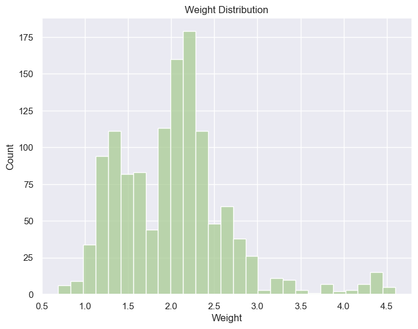

```python
#Weight Distribution
plt.figure(figsize=(8,6))

sns.histplot(df.Weight,color="#A9CC94")
plt.title("Weight Distribution")
plt.xlabel("Weight")
plt.ylabel("Count")

plt.show()
```

•The weight distribution of laptops shows that the majority fall within the 1.5 to 2.5 kg range, indicating a preference for lightweight and portable devices. Heavier laptops, exceeding 3 kg, are less common, likely representing specialized models such as gaming or workstation laptops. This distribution reflects the market's focus on portability and convenience for everyday use.

```python
#Price Correlation Analysis
corr_map=df.select_dtypes(include=["int","float"]).corr()
corr_map
```

|  | Inches | Ram | Weight | Price |
| --- | --- | --- | --- | --- |
| Inches | 1.000000 | 0.219750 | 0.826893 | 0.020534 |
| Ram | 0.219750 | 1.000000 | 0.354050 | 0.723397 |
| Weight | 0.826893 | 0.354050 | 1.000000 | 0.154078 |
| Price | 0.020534 | 0.723397 | 0.154078 | 1.000000 |

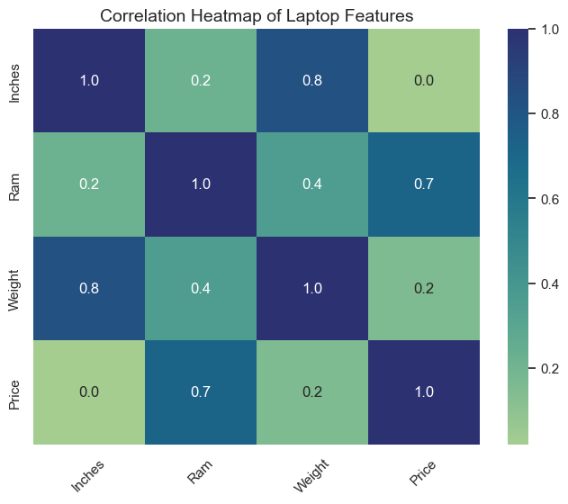

```python
plt.figure(figsize=(8,6))
sns.heatmap(corr_map, annot=True, fmt=".1f", cmap="crest")
plt.title("Correlation Heatmap of Laptop Features",fontsize=14)
plt.xlabel("", fontsize=12)
plt.xticks(rotation=45)
plt.show()
```

•The correlation analysis shows the relationships between various numerical features of laptops.

•The strongest correlation with price is observed for RAM (0.72), indicating that RAM size significantly impacts laptop prices.

•Weight and screen size (Inches) have weak correlations with price (0.15 and 0.02, respectively), suggesting that these features are less influential in determining cost.

•Additionally, weight and screen size are strongly correlated (0.83), reflecting that larger laptops tend to weigh more. This analysis highlights RAM as a key driver of pricing.

```python
#ScreenResolution Impact on Price
df.groupby("PanelType")[["Price"]].mean()
```

| PanelType | Price |
| --- | --- |
| 4K Ultra HD | 118000.074444 |
| Full HD | 64714.040977 |
| Quad HD+ | 85653.993704 |
| Retina Display | 88330.498235 |
| Touchscreen | 63941.150222 |
| Touchscreen / 4K Ultra HD | 77765.356667 |
| Touchscreen / Full HD | 72354.240000 |
| Touchscreen / Quad HD+ | 99580.320000 |
| Unknown | 32548.349804 |

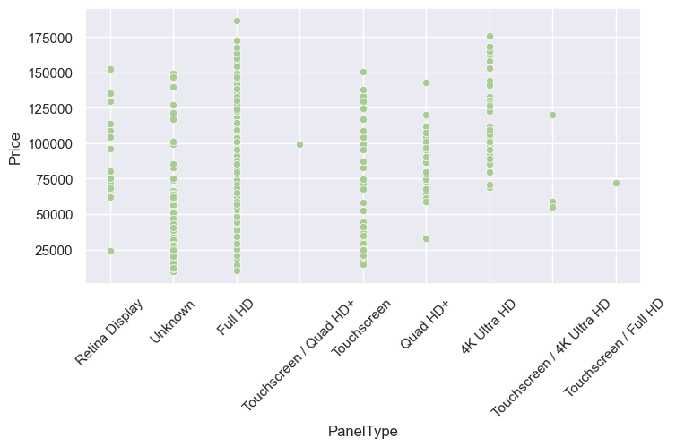

```python
plt.figure(figsize=(8,4))
sns.scatterplot(x=df.PanelType,y=df.Price,color="#A9CC94");
plt.xticks(rotation=45)

plt.show()
```

•Full HD and standard touchscreen panels are relatively more affordable, while laptops with "Unknown" panel types are the least expensive.

•This suggests that higher resolution and advanced display technologies significantly contribute to laptop pricing.

```python
#Top CPU/GPU Manufacturers
```

```python
df.Cpu.value_counts().nlargest(10)
```

```
Cpu
Intel Core i5 7200U 2.5GHz     190
Intel Core i7 7700HQ 2.8GHz    144
Intel Core i7 7500U 2.7GHz     132
Intel Core i7 8550U 1.8GHz      73
Intel Core i5 8250U 1.6GHz      72
Intel Core i5 6200U 2.3GHz      68
Intel Core i3 6006U 2GHz        64
Intel Core i7 6500U 2.5GHz      41
Intel Core i7 6700HQ 2.6GHz     40
Intel Core i3 7100U 2.4GHz      35
Name: count, dtype: int64
```

```python
df.Gpu.value_counts()
```

```
Gpu
Intel HD Graphics 620      279
Intel HD Graphics 520      181
Intel UHD Graphics 620      68
Nvidia GeForce GTX 1050     66
Nvidia GeForce GTX 1060     48
                          ...
Nvidia GTX 980 SLI           1
AMD Radeon R7                1
Intel HD Graphics 540        1
AMD Radeon 540               1
ARM Mali T860 MP4            1
Name: count, Length: 107, dtype: int64
```

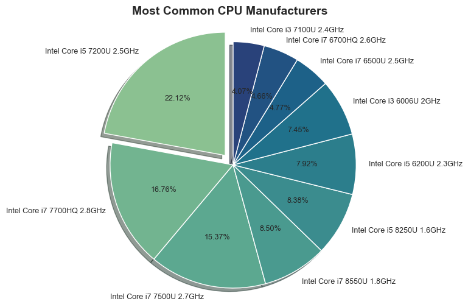

```python
fig, ax = plt.subplots(figsize=(8,6))
values = df.Cpu.value_counts().nlargest(10).values
explode = [0.1] + [0] * (len(values) - 1)
colors = sns.color_palette("crest", 10)

ax.pie(df.Cpu.value_counts().nlargest(10).values, labels=df.Cpu.value_counts().nlargest(10).index, autopct='%1.2f%%', startangle=90,
       explode=explode, shadow = 0.1, textprops={'fontsize': 9},colors=colors)


ax.set_title('Most Common CPU Manufacturers', fontsize=14, fontweight='bold')
ax.axis('equal')

plt.show()
```

•The Intel Core i5 7200U (2.5GHz) is the most commonly used processor, followed by the Intel Core i7 7700HQ (2.8GHz) and Core i7 7500U (2.7GHz).

•This indicates a preference for mid-range and high-performance Intel processors in laptops.

•The distribution also reflects that Intel dominates the CPU market, with consistent use of its i5 and i7 series across different models and configurations.

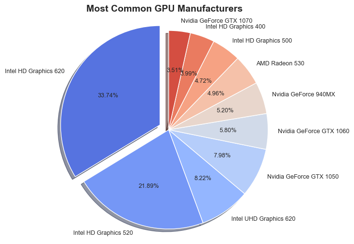

```python
fig, ax = plt.subplots(figsize=(8,6))
values = df.Gpu.value_counts().nlargest(10).values
explode = [0.1] + [0] * (len(values) - 1)
colors = sns.color_palette("coolwarm", 10)

ax.pie(df.Gpu.value_counts().nlargest(10).values, labels=df.Gpu.value_counts().nlargest(10).index, autopct='%1.2f%%', startangle=90,
       explode=explode, shadow = 0.1, textprops={'fontsize': 9},colors=colors)


ax.set_title('Most Common GPU Manufacturers', fontsize=14, fontweight='bold')
ax.axis('equal')

plt.show()
```

•The analysis of GPUs shows that integrated graphics, such as Intel HD Graphics 620 and 520, dominate the market, indicating a prevalence of laptops designed for general-purpose or lightweight tasks.

•Discrete GPUs like Nvidia GeForce GTX 1050 and GTX 1060 are less common, typically found in laptops intended for gaming or high-performance applications.

•AMD GPUs have minimal representation, reflecting their smaller market share compared to Intel and Nvidia in this dataset.

```python
#RAM Analysis
df.Ram.value_counts()
```

```
Ram
8     612
4     366
16    197
6      35
12     25
2      16
32     11
24      3
Name: count, dtype: int64
```

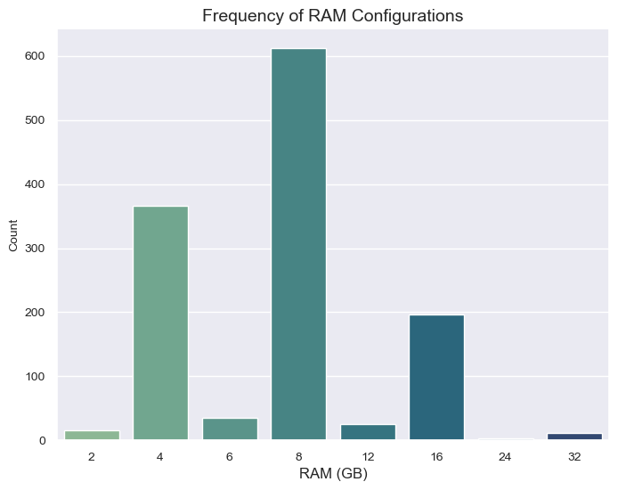

```python
plt.figure(figsize=(8,6))
sns.barplot(x=df.Ram.value_counts().index, y=df.Ram.value_counts().values, palette="crest")
plt.title("Frequency of RAM Configurations", fontsize=14)
plt.xlabel("RAM (GB)", fontsize=12)
plt.ylabel("Count", fontsize=10)
plt.xticks(fontsize=10)
plt.yticks(fontsize=10)
plt.show()
```

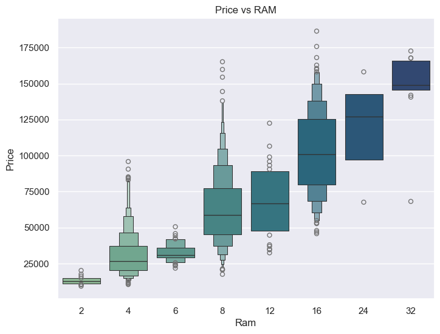

```python
plt.figure(figsize=(8,6))
sns.boxenplot(x=df.Ram,y=df.Price,palette="crest")
plt.title("Price vs RAM")
plt.show()
```

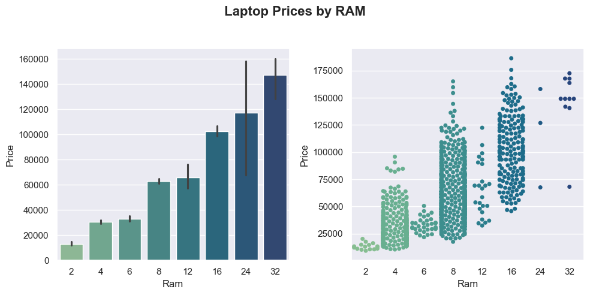

```python
fig, axes=plt.subplots(1,2,figsize=(10,5))

sns.barplot(x=df.Ram,y=df.Price,palette="crest",ax=axes[0])
axes[0].set_xlabel("Ram")
axes[0].set_ylabel("Price")

sns.swarmplot(x=df.Ram,y=df.Price,palette="crest",ax=axes[1])
axes[1].set_xlabel("Ram")
axes[1].set_ylabel("Price")

fig.suptitle("Laptop Prices by RAM", fontsize=16, fontweight="bold")

plt.tight_layout(rect=[0, 0, 1, 0.95])
plt.show()
```

•The frequency distribution of RAM configurations reveals that 8GB RAM is the most common, followed by 4GB and 16GB.This indicates that the majority of laptops target mid-range performance needs, suitable for general use or moderate multitasking.

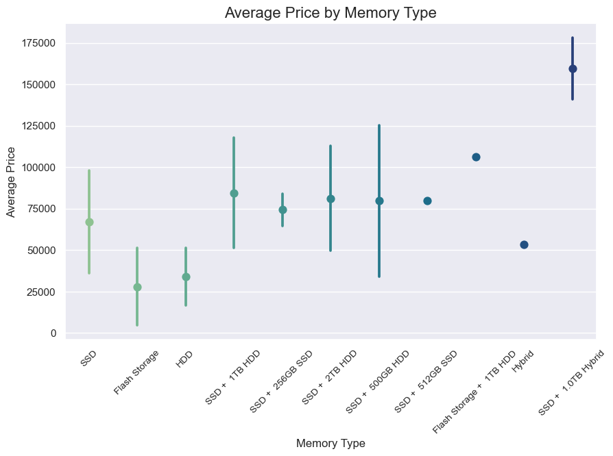

```python
#Memory Type and Price Relationship
plt.figure(figsize=(10,6))

sns.pointplot(x=df["MemoryType"], y=df["Price"], palette="crest", ci="sd")
plt.title("Average Price by Memory Type", fontsize=16)
plt.xlabel("Memory Type", fontsize=12)
plt.ylabel("Average Price", fontsize=12)
plt.xticks(rotation=45,size=10)
plt.show()
```

•The chart shows that laptops with SSDs, especially high-capacity or hybrid configurations, have higher average prices compared to HDDs. This reflects the premium associated with faster storage technologies.

```python
#High-end Laptop Analysis
price_threshold = df['Price'].quantile(0.8)
high_end = (
    (df['Price'] >= price_threshold) &
    (df['Ram'] >= 16) &
    (df['Cpu'].str.contains('i7|i9', case=False)) &
    (df['Gpu'].str.contains('Nvidia|AMD', case=False))
)
```

```python
df[high_end]
```

|  | Company | TypeName | Inches | Cpu | Ram | Gpu | OpSys | Weight | Price | MemorySize | MemoryType | Brand | ClockSpeed | PanelType | Resolution | Touchscreen |
| --- | --- | --- | --- | --- | --- | --- | --- | --- | --- | --- | --- | --- | --- | --- | --- | --- |
| 3 | Apple | Ultrabook | 15.4 | Intel Core i7 2.7GHz | 16 | AMD Radeon Pro 455 | Mac | 1.83 | 135195.34 | 512GB | SSD | Intel | 2.7GHz | Retina Display | 2880x1800 | No |
| 12 | Apple | Ultrabook | 15.4 | Intel Core i7 2.8GHz | 16 | AMD Radeon Pro 555 | Mac | 1.83 | 130001.60 | 256GB | SSD | Intel | 2.8GHz | Retina Display | 2880x1800 | No |
| 17 | Apple | Ultrabook | 15.4 | Intel Core i7 2.9GHz | 16 | AMD Radeon Pro 560 | Mac | 1.83 | 152274.24 | 512GB | SSD | Intel | 2.9GHz | Retina Display | 2880x1800 | No |
| 58 | MSI | Gaming | 17.3 | Intel Core i7 7700HQ 2.8GHz | 16 | Nvidia GeForce GTX 1070 | Windows | 2.43 | 130482.72 | 256GB | SSD + 2TB HDD | Intel | 2.8GHz | Full HD | 1920x1080 | No |
| 65 | Asus | Ultrabook | 15.6 | Intel Core i7 7700HQ 2.8GHz | 16 | Nvidia GeForce GTX 1050 Ti | Windows | 1.80 | 105654.24 | 512GB | SSD | Intel | 2.8GHz | Full HD | 1920x1080 | No |
| ... | ... | ... | ... | ... | ... | ... | ... | ... | ... | ... | ... | ... | ... | ... | ... | ... |
| 1214 | Asus | Gaming | 17.3 | Intel Core i7 7700HQ 2.8GHz | 16 | Nvidia GeForce GTX 1060 | Windows | 2.90 | 103842.72 | 256GB | SSD + 1TB HDD | Intel | 2.8GHz | Full HD | 1920x1080 | No |
| 1231 | Razer | Gaming | 14.0 | Intel Core i7 7700HQ 2.8GHz | 16 | Nvidia GeForce GTX 1060 | Windows | 1.95 | 186426.72 | NaN | NaN | Intel | 2.8GHz | Full HD | 1920x1080 | No |
| 1243 | Dell | 2 in 1 Convertible | 17.3 | Intel Core i7 7500U 2.7GHz | 16 | Nvidia GeForce 940MX | Windows | 2.77 | 95850.72 | 512GB | SSD | Intel | 2.7GHz | Full HD | 1920x1080 | Yes |
| 1247 | Asus | Gaming | 15.6 | Intel Core i7 6700HQ 2.6GHz | 16 | Nvidia GeForce GTX 1070 | Windows | 2.34 | 123876.00 | 256GB | SSD + 1TB HDD | Intel | 2.6GHz | Full HD | 1920x1080 | No |
| 1256 | Asus | Gaming | 17.3 | Intel Core i7 6700HQ 2.6GHz | 16 | Nvidia GeForce GTX 970M | Windows | 4.00 | 101232.00 | 128GB | SSD + 1TB HDD | Intel | 2.6GHz | Full HD | 1920x1080 | No |

99 rows × 16 columns

```python
#TypeName Analysis
df.groupby("TypeName")[["Price"]].agg( Max=('Price', np.max),
    Min=('Price', np.min),
    Sum=('Price', np.sum),
    Mean=('Price', np.mean))
```

| TypeName | Max | Min | Sum | Mean |
| --- | --- | --- | --- | --- |
| 2 in 1 Convertible | 150462.72 | 14652.00 | 8039770.85 | 68715.990171 |
| Gaming | 186426.72 | 37242.72 | 17487659.09 | 87877.683869 |
| Netbook | 101658.24 | 9270.72 | 825189.98 | 35877.825217 |
| Notebook | 159786.72 | 10442.88 | 29430516.57 | 41745.413574 |
| Ultrabook | 165168.00 | 26586.72 | 16090301.59 | 82939.698918 |
| Workstation | 175770.72 | 72940.32 | 3079158.30 | 114042.900000 |

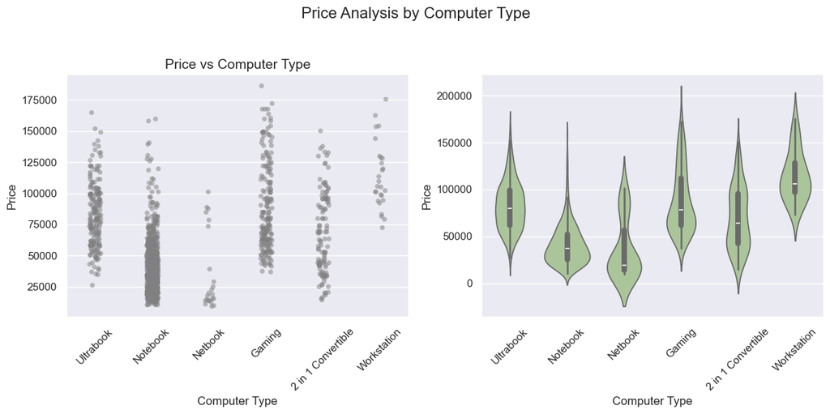

```python
plt.figure(figsize=(10,5))
fig, axes = plt.subplots(1, 2, figsize=(12, 6))

sns.stripplot(x=df["TypeName"], y=df["Price"], jitter=True, color="gray", alpha=0.5, ax=axes[0])
axes[0].set_title("Price vs Computer Type", fontsize=14)
axes[0].set_xlabel("Computer Type", fontsize=12)
axes[0].set_ylabel("Price", fontsize=12)
axes[0].tick_params(axis='x', rotation=45)

sns.violinplot(x=df["TypeName"], y=df["Price"], color="#A9CC94", ax=axes[1])
axes[1].set_xlabel("Computer Type", fontsize=12)
axes[1].set_ylabel("Price", fontsize=12)
axes[1].tick_params(axis='x', rotation=45)

fig.subplots_adjust(wspace=0.4)

fig.suptitle("Price Analysis by Computer Type", fontsize=16)

plt.tight_layout(rect=[0, 0, 1, 0.95])
plt.show()
```

•The analyze shows that gaming laptops and workstations generally have higher prices compared to ultrabooks and notebooks, reflecting their specialized hardware and performance capabilities. Netbooks are the least expensive, targeting budget users.

```python
#Let's analyze to understand the relationship between touchscreen availability and device pricing, highlighting how touchscreen features influence overall costs.
new_pivot=df.pivot_table(index="Touchscreen",values="Price")*100
new_pivot
```

| Touchscreen | Price |
| --- | --- |
| No | 5.654789e+06 |
| Yes | 7.493236e+06 |

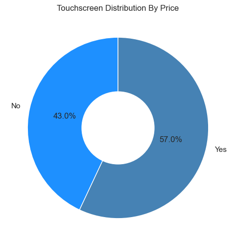

```python
plt.figure(figsize=(8, 6))

colors = ['#1E90FF', '#4682B4']
plt.pie(
    new_pivot["Price"],
    labels=new_pivot.index,
    autopct='%1.1f%%',
    startangle=90,
    colors=colors,
    wedgeprops={'width': 0.7}
)


plt.gca().add_artist(plt.Circle((0, 0), 0.4, color='white'))

plt.title("Touchscreen Distribution By Price")
plt.show()
```

# 📌CONCLUSION

✲The analysis provides valuable insights into the laptop market. Key findings include:

**✔Price Influencers:** RAM size, storage type, and panel quality significantly affect laptop pricing, with higher configurations leading to higher costs.

**✔Market Trends:** Windows is the most widely used operating system, and Intel dominates the CPU and GPU space.

**✔Diversity:** Gaming laptops and workstations are priced higher, catering to niche, high-performance markets, while netbooks target budget users.

✲These insights highlight trends in the laptop market, helping to understand pricing strategies and consumer preferences.

🚀Thank you for taking the time to explore this analysis—your engagement and interest are greatly appreciated!